# HW 03 - Great Lakes Fish Datasets

Kayode Ayegbusi

02/15/2023

## Load packages and data

```r
library(tidyverse)
```

```r
catch_data <- readr::read_csv('https://raw.githubusercontent.com/rfordatascience/tidytuesday/master/data/2021/2021-06-08/fishing.csv')

fish_stock <- read_csv("data/great-lakes-fish-stock.csv")
```

## Exercises

### Exercise 1

```r
# select the columns of interest and save to overwrite the original dataframe object
catch_data <- catch_data %>%
  select(year, lake, species, region, values)
```

```r
#select the columns of interest and save to overwrite the original dataframe object
fish_stock <- fish_stock %>%
  select(YEAR, MONTH, LAKE, STATE_PROV, SPECIES, WEIGHT)
```

### Exercise 2

```r
#review the selected columns stored in catch_data
glimpse(catch_data)
```

```
## Rows: 65,706
## Columns: 5
## $ year    <dbl> 1991, 1991, 1991, 1991, 1991, 1991, 1992, 1992, 1992, 1992, 19…
## $ lake    <chr> "Erie", "Erie", "Erie", "Erie", "Erie", "Erie", "Erie", "Erie"…
## $ species <chr> "American Eel", "American Eel", "American Eel", "American Eel"…
## $ region  <chr> "Michigan (MI)", "New York (NY)", "Ohio (OH)", "Pennsylvania (…
## $ values  <dbl> 0, 0, 0, 0, 0, 1, 0, 0, 0, 0, 0, 0, 0, 0, 0, 0, 0, 0, 0, 0, 0,…
```

```r
#review the selected columns stored in fish_stock
glimpse(fish_stock)
```

```
## Rows: 56,232
## Columns: 6
## $ YEAR       <dbl> 1950, 1952, 1952, 1952, 1953, 1953, 1953, 1953, 1953, 1954,…
## $ MONTH      <dbl> NA, 4, 9, NA, 5, 10, NA, NA, NA, 6, 10, NA, NA, NA, NA, NA,…
## $ LAKE       <chr> "MI", "SU", "SU", "SU", "SU", "SU", "SU", "SU", "SU", "SU",…
## $ STATE_PROV <chr> "ON", "WI", "WI", "MI", "WI", "WI", "MI", "MI", "ON", "WI",…
## $ SPECIES    <chr> "LAT", "LAT", "LAT", "LAT", "LAT", "LAT", "LAT", "LAT", "LA…
## $ WEIGHT     <dbl> NA, 816.78, 870.00, 588.29, 1442.47, 664.90, 902.71, 695.37…
```

### Exercise 3

```r
# I want to filter out other information in the catch_data of no interest and retain data of interest
catch_data <- catch_data %>%
  filter(region == "U.S. Total",
         species ==  "Chinook Salmon",
         lake == "Michigan",
         eval(TRUE))
catch_data
```

```
## # A tibble: 17 × 5
##     year lake     species        region     values
##    <dbl> <chr>    <chr>          <chr>       <dbl>
##  1  1992 Michigan Chinook Salmon U.S. Total      7
##  2  1993 Michigan Chinook Salmon U.S. Total      6
##  3  1994 Michigan Chinook Salmon U.S. Total     43
##  4  1995 Michigan Chinook Salmon U.S. Total     57
##  5  1996 Michigan Chinook Salmon U.S. Total     47
##  6  1997 Michigan Chinook Salmon U.S. Total     29
##  7  1998 Michigan Chinook Salmon U.S. Total     27
##  8  1999 Michigan Chinook Salmon U.S. Total      8
##  9  2007 Michigan Chinook Salmon U.S. Total      4
## 10  2008 Michigan Chinook Salmon U.S. Total      5
## 11  2009 Michigan Chinook Salmon U.S. Total      3
## 12  2010 Michigan Chinook Salmon U.S. Total      2
## 13  2011 Michigan Chinook Salmon U.S. Total      7
## 14  2012 Michigan Chinook Salmon U.S. Total      3
## 15  2013 Michigan Chinook Salmon U.S. Total      3
## 16  2014 Michigan Chinook Salmon U.S. Total      1
## 17  2015 Michigan Chinook Salmon U.S. Total      0
```

```r
# I want to filter out other information in the fish_stock of no interest and retain data of interest
fish_stock <- fish_stock %>%
  filter("MI" %in% c("MI","WI", "IL", "IN"),
        SPECIES == "CHS",
        LAKE == "MI",
        eval(TRUE))
fish_stock
```

```
## # A tibble: 2,395 × 6
##     YEAR MONTH LAKE  STATE_PROV SPECIES WEIGHT
##    <dbl> <dbl> <chr> <chr>      <chr>    <dbl>
##  1  1967    NA MI    MI         CHS         NA
##  2  1967    NA MI    MI         CHS         NA
##  3  1968    NA MI    MI         CHS         NA
##  4  1968    NA MI    MI         CHS         NA
##  5  1969    NA MI    MI         CHS         NA
##  6  1969    NA MI    MI         CHS         NA
##  7  1969    NA MI    WI         CHS         NA
##  8  1970    NA MI    MI         CHS         NA
##  9  1970    NA MI    MI         CHS         NA
## 10  1970    NA MI    IL         CHS         NA
## # … with 2,385 more rows
```

### Exercise 4

There are 17 observations and 5 variables in the catch_data data set. The first year in the catch_data is 1992 The last year in the catch_data is 2015

There are 2395 observations and 6 variables in the fish_stock data set. The first year in the catch_data is 1967 The last year in the catch_data is 2018

### Exercise 5

```r
#turn the monthly weight of the fish stock to yearly weight using group_by function and summarise()
fish_stock_yearly <- fish_stock %>%
  group_by(YEAR) %>%
  summarise(STOCK_WEIGHT_YR = sum(WEIGHT, na.rm = T))
```

### Code chunks provided

Remember to change eval = FALSE, to eval = TRUE, when you are ready to run the code/knit the document.

```r
fish_stock_yearly <- fish_stock_yearly %>%
# rename the variable so that the two dataframes have thesame format that can be combined together
  rename(year = YEAR) %>%
# use mutate to convert the weight from kg to lbs
  mutate(stock_weight_yr_lbs = as.integer(STOCK_WEIGHT_YR * 0.454 / 1000)) %>% # 1 lb = 1 kg * 0.454
  select(year, stock_weight_yr_lbs)
```

```r
catch_data <- catch_data %>%
# rename the variable values to catch_weight_yr_lbs
rename(catch_weight_yr_lbs = values)
```

### Exercise 6

```r
#use left_join function to join the two data sets together
left_join(catch_data, fish_stock_yearly)
```

```
## # A tibble: 17 × 6
##     year lake     species        region     catch_weight_yr_lbs stock_weight_y…¹
##    <dbl> <chr>    <chr>          <chr>                    <dbl>            <int>
##  1  1992 Michigan Chinook Salmon U.S. Total                   7               12
##  2  1993 Michigan Chinook Salmon U.S. Total                   6               10
##  3  1994 Michigan Chinook Salmon U.S. Total                  43               12
##  4  1995 Michigan Chinook Salmon U.S. Total                  57               13
##  5  1996 Michigan Chinook Salmon U.S. Total                  47               19
##  6  1997 Michigan Chinook Salmon U.S. Total                  29               17
##  7  1998 Michigan Chinook Salmon U.S. Total                  27               16
##  8  1999 Michigan Chinook Salmon U.S. Total                   8               15
##  9  2007 Michigan Chinook Salmon U.S. Total                   4               13
## 10  2008 Michigan Chinook Salmon U.S. Total                   5               12
## 11  2009 Michigan Chinook Salmon U.S. Total                   3               12
## 12  2010 Michigan Chinook Salmon U.S. Total                   2               12
## 13  2011 Michigan Chinook Salmon U.S. Total                   7               11
## 14  2012 Michigan Chinook Salmon U.S. Total                   3               11
## 15  2013 Michigan Chinook Salmon U.S. Total                   3                7
## 16  2014 Michigan Chinook Salmon U.S. Total                   1                8
## 17  2015 Michigan Chinook Salmon U.S. Total                   0                8
## # … with abbreviated variable name ¹stock_weight_yr_lbs
```

The line of code produced a combined dataset that has seventeen rows (observations) and six columns (variables), this combination retains common observations in both datasets and eliminate observations in fish_stock_yearly not found in catch_data but retains observations in catch_data not found in fish_stock_yearly.

```r
#use right_join function to join the two data sets together
right_join(catch_data, fish_stock_yearly)
```

```
## # A tibble: 52 × 6
##     year lake     species        region     catch_weight_yr_lbs stock_weight_y…¹
##    <dbl> <chr>    <chr>          <chr>                    <dbl>            <int>
##  1  1992 Michigan Chinook Salmon U.S. Total                   7               12
##  2  1993 Michigan Chinook Salmon U.S. Total                   6               10
##  3  1994 Michigan Chinook Salmon U.S. Total                  43               12
##  4  1995 Michigan Chinook Salmon U.S. Total                  57               13
##  5  1996 Michigan Chinook Salmon U.S. Total                  47               19
##  6  1997 Michigan Chinook Salmon U.S. Total                  29               17
##  7  1998 Michigan Chinook Salmon U.S. Total                  27               16
##  8  1999 Michigan Chinook Salmon U.S. Total                   8               15
##  9  2007 Michigan Chinook Salmon U.S. Total                   4               13
## 10  2008 Michigan Chinook Salmon U.S. Total                   5               12
## # … with 42 more rows, and abbreviated variable name ¹stock_weight_yr_lbs
```

The line of code produced a combined dataset that has fiftytwo rows (observations) and six columns (variables), this combination retains common observations in both datasets and eliminate observations in catch_data not found in fish_stock_yearly but retains observations in fish_stock_yearly not found in catch_data.

```r
#use inner_join function to join the two data sets together
inner_join(catch_data, fish_stock_yearly)
```

```
## # A tibble: 17 × 6
##     year lake     species        region     catch_weight_yr_lbs stock_weight_y…¹
##    <dbl> <chr>    <chr>          <chr>                    <dbl>            <int>
##  1  1992 Michigan Chinook Salmon U.S. Total                   7               12
##  2  1993 Michigan Chinook Salmon U.S. Total                   6               10
##  3  1994 Michigan Chinook Salmon U.S. Total                  43               12
##  4  1995 Michigan Chinook Salmon U.S. Total                  57               13
##  5  1996 Michigan Chinook Salmon U.S. Total                  47               19
##  6  1997 Michigan Chinook Salmon U.S. Total                  29               17
##  7  1998 Michigan Chinook Salmon U.S. Total                  27               16
##  8  1999 Michigan Chinook Salmon U.S. Total                   8               15
##  9  2007 Michigan Chinook Salmon U.S. Total                   4               13
## 10  2008 Michigan Chinook Salmon U.S. Total                   5               12
## 11  2009 Michigan Chinook Salmon U.S. Total                   3               12
## 12  2010 Michigan Chinook Salmon U.S. Total                   2               12
## 13  2011 Michigan Chinook Salmon U.S. Total                   7               11
## 14  2012 Michigan Chinook Salmon U.S. Total                   3               11
## 15  2013 Michigan Chinook Salmon U.S. Total                   3                7
## 16  2014 Michigan Chinook Salmon U.S. Total                   1                8
## 17  2015 Michigan Chinook Salmon U.S. Total                   0                8
## # … with abbreviated variable name ¹stock_weight_yr_lbs
```

```r
inner_join(fish_stock_yearly, catch_data)
```

```
## # A tibble: 17 × 6
##     year stock_weight_yr_lbs lake     species        region     catch_weight_y…¹
##    <dbl>               <int> <chr>    <chr>          <chr>                 <dbl>
##  1  1992                  12 Michigan Chinook Salmon U.S. Total                7
##  2  1993                  10 Michigan Chinook Salmon U.S. Total                6
##  3  1994                  12 Michigan Chinook Salmon U.S. Total               43
##  4  1995                  13 Michigan Chinook Salmon U.S. Total               57
##  5  1996                  19 Michigan Chinook Salmon U.S. Total               47
##  6  1997                  17 Michigan Chinook Salmon U.S. Total               29
##  7  1998                  16 Michigan Chinook Salmon U.S. Total               27
##  8  1999                  15 Michigan Chinook Salmon U.S. Total                8
##  9  2007                  13 Michigan Chinook Salmon U.S. Total                4
## 10  2008                  12 Michigan Chinook Salmon U.S. Total                5
## 11  2009                  12 Michigan Chinook Salmon U.S. Total                3
## 12  2010                  12 Michigan Chinook Salmon U.S. Total                2
## 13  2011                  11 Michigan Chinook Salmon U.S. Total                7
## 14  2012                  11 Michigan Chinook Salmon U.S. Total                3
## 15  2013                   7 Michigan Chinook Salmon U.S. Total                3
## 16  2014                   8 Michigan Chinook Salmon U.S. Total                1
## 17  2015                   8 Michigan Chinook Salmon U.S. Total                0
## # … with abbreviated variable name ¹catch_weight_yr_lbs
```

This line of code produced a combined dataset that only retains the observations in both datasets that matched and eliminates observation in catch_data that are not present in fish_stock_yearly and vice versa.

```r
#use full_join function to join the two data sets together
full_join(catch_data, fish_stock_yearly)
```

```
## # A tibble: 52 × 6
##     year lake     species        region     catch_weight_yr_lbs stock_weight_y…¹
##    <dbl> <chr>    <chr>          <chr>                    <dbl>            <int>
##  1  1992 Michigan Chinook Salmon U.S. Total                   7               12
##  2  1993 Michigan Chinook Salmon U.S. Total                   6               10
##  3  1994 Michigan Chinook Salmon U.S. Total                  43               12
##  4  1995 Michigan Chinook Salmon U.S. Total                  57               13
##  5  1996 Michigan Chinook Salmon U.S. Total                  47               19
##  6  1997 Michigan Chinook Salmon U.S. Total                  29               17
##  7  1998 Michigan Chinook Salmon U.S. Total                  27               16
##  8  1999 Michigan Chinook Salmon U.S. Total                   8               15
##  9  2007 Michigan Chinook Salmon U.S. Total                   4               13
## 10  2008 Michigan Chinook Salmon U.S. Total                   5               12
## # … with 42 more rows, and abbreviated variable name ¹stock_weight_yr_lbs
```

This line of code produced a combination of all the observations in both datasets.

```r
catch_data %>%
  anti_join(fish_stock_yearly)
```

```
## # A tibble: 0 × 5
## # … with 5 variables: year <dbl>, lake <chr>, species <chr>, region <chr>,
## #   catch_weight_yr_lbs <dbl>
```

This code produced zero combination because every observation in catch_data are present in fish_stock_yearly data set

```r
fish_stock_yearly %>%
  anti_join(catch_data)
```

```
## # A tibble: 35 × 2
##     year stock_weight_yr_lbs
##    <dbl>               <int>
##  1  1967                   0
##  2  1968                   0
##  3  1969                   0
##  4  1970                   0
##  5  1971                   0
##  6  1972                   0
##  7  1973                   0
##  8  1974                   0
##  9  1975                   0
## 10  1976                   0
## # … with 25 more rows
```

This code produced a dataset that retains only the observations that are present in fish_stock_yearly but absent in catch_data

### Exercise 7

```r
catch_data %>%
  left_join(fish_stock_yearly) %>%
  pivot_longer(names_to = "activity",
               values_to = "catch_weight_yr_lbs",
               cols = 5:6)
```

```
## # A tibble: 34 × 6
##     year lake     species        region     activity            catch_weight_y…¹
##    <dbl> <chr>    <chr>          <chr>      <chr>                          <dbl>
##  1  1992 Michigan Chinook Salmon U.S. Total catch_weight_yr_lbs                7
##  2  1992 Michigan Chinook Salmon U.S. Total stock_weight_yr_lbs               12
##  3  1993 Michigan Chinook Salmon U.S. Total catch_weight_yr_lbs                6
##  4  1993 Michigan Chinook Salmon U.S. Total stock_weight_yr_lbs               10
##  5  1994 Michigan Chinook Salmon U.S. Total catch_weight_yr_lbs               43
##  6  1994 Michigan Chinook Salmon U.S. Total stock_weight_yr_lbs               12
##  7  1995 Michigan Chinook Salmon U.S. Total catch_weight_yr_lbs               57
##  8  1995 Michigan Chinook Salmon U.S. Total stock_weight_yr_lbs               13
##  9  1996 Michigan Chinook Salmon U.S. Total catch_weight_yr_lbs               47
## 10  1996 Michigan Chinook Salmon U.S. Total stock_weight_yr_lbs               19
## # … with 24 more rows, and abbreviated variable name ¹catch_weight_yr_lbs
```

### Exercise 8

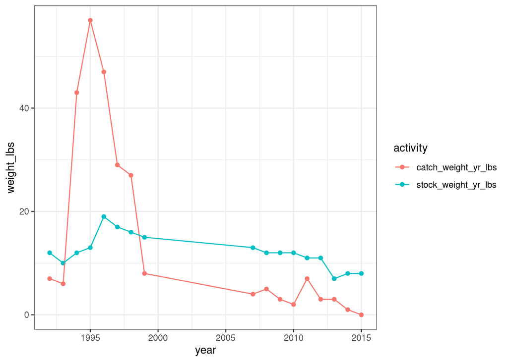

```r
catch_data %>%
  left_join(fish_stock_yearly) %>%
  pivot_longer(names_to = "activity",
               values_to = "weight_lbs",
               cols = 5:6) %>%
  ggplot(aes(x = year, y = weight_lbs, color = activity)) +
  geom_point() +
  geom_line() +
  theme_bw()
```

The trend reached it peak in the mid 1990s, specifically 1995 for catch_weight_yr_lbs dataset but have been decline ever since.